# Weekends Clean the Air of Traffic Pollution, but Not of Ozone

Weekly cycles in US urban air quality, 2000-2023

Author

Soham

Published

July 28, 2026

# Introduction

## The data

This report uses the US Air Quality Metrics dataset, which compiles daily readings from Environmental Protection Agency monitoring stations between January 2000 and September 2023. The raw file contains 665,414 monitor-days across 21 measured columns, covering 48 states and 150 cities. For each monitor-day it records the daily mean, the daily maximum, the hour of that maximum, and the Air Quality Index for four pollutants: nitrogen dioxide (NO<sub>2</sub>), ozone (O<sub>3</sub>), carbon monoxide (CO), and sulphur dioxide (SO<sub>2</sub>).

Table 1: Summary statistics for the two outcome variables, measured across the analysis sample.

| Pollutant | N | Mean | SD | Median | IQR |
| --- | --- | --- | --- | --- | --- |
| Nitrogen dioxide (NO2) | 212,807 | 13.724 | 9.228 | 11.636 | 11.875 |
| Ozone (O3) | 212,807 | 0.028 | 0.012 | 0.028 | 0.017 |

After cleaning and restricting to the 20 best-covered monitoring locations, the analysis sample contains 212,807 monitor-days spanning 2000 to 2023. Nitrogen dioxide, the primary outcome, averages 13.7 ppb with a standard deviation of 9.2 ppb.

## Code book

Table 2 defines every variable used in the analysis, including the derived calendar variables.

Table 2: Data dictionary for all variables used in the analysis.

| Variable | Type | Description |
| --- | --- | --- |
| date | Date | Calendar date of the monitor reading (2000-01-01 to 2023-09-30). |
| state | character | US state containing the monitoring site. |
| city | character | City containing the monitoring site. |
| location | factor | State and city combined. Used as a fixed effect because three city names appear in more than one state. |
| no2_mean | numeric | Primary outcome. Mean nitrogen dioxide concentration for the day, in parts per billion. Used as a marker of vehicle exhaust. |
| o3_mean | numeric | Second outcome. Mean ground-level ozone concentration for the day, in parts per million. Ozone is formed by photochemistry, not emitted directly. |
| co_mean | numeric | Mean carbon monoxide concentration, retained for the appendix check. |
| so2_mean | numeric | Mean sulphur dioxide concentration, retained for the appendix check. |
| day_of_week | factor | Day of the week, with Wednesday as the regression reference level. |
| is_weekend | factor | Weekday or Weekend. The primary predictor of interest. |
| month | factor | Calendar month, included to absorb strong seasonal cycles. |
| year | factor | Calendar year, included to absorb long-run emission trends. |

## Variables omitted, and observations dropped

The raw file carries several columns that this analysis does not use. Table 3 records each omission and the reason for it.

Table 3: Raw variables excluded from the analysis, with justification.

| Variable | Reason |
| --- | --- |
| Address | Street address of the monitor. Superseded by the coarser location factor, which gives more observations per level. |
| County | Redundant once state and city identify the monitoring site. |
| * 1st Max Value, * 1st Max Hour | Daily maxima and their timing describe short peaks rather than the daily burden this analysis models. |
| * AQI | AQI is a piecewise, non-linear rescaling of the same concentration readings, so modelling it would distort the percentage comparisons. |

Two cleaning rules remove observations, and Table 4 reports the cost of each. First, monitors occasionally report zero or slightly negative concentrations when true levels sit near the instrument detection limit. These readings are physically impossible and undefined under the log transformation used below, so they are dropped. Second, a small number of monitors carry the placeholder city label “Not in a city” and cannot be tied to an urban area, so they are dropped as well. Together these rules remove roughly 9% of the raw file, and neither rule depends on the day of the week, so neither should bias a weekday-versus-weekend comparison.

Table 4: Observations remaining after each cleaning step.

| Cleaning stage | Rows remaining | Rows dropped |
| --- | --- | --- |
| Raw observations | 665,414 | NA |
| Remove non-positive NO2 or O3 readings | 660,963 | 4,451 |
| Remove monitors with no city assigned | 607,562 | 53,401 |

The analysis then restricts attention to the 20 locations with the most complete records. This keeps the panel balanced across the full 24-year window and concentrates on dense urban monitors, where any traffic signal should be strongest. The cost of this choice is discussed in the critique.

## Motivation

Nitrogen dioxide in cities comes overwhelmingly from combustion, and in particular from motor vehicle exhaust. Commuting traffic follows a sharp weekly rhythm, so if vehicle emissions drive urban NO<sub>2</sub>, concentrations should fall on Saturdays and Sundays. This “weekend effect” is a natural experiment that repeats every seven days for 24 years, which makes it an unusually clean way to look for a human fingerprint in environmental data.

Ozone is the interesting complication. Ground-level ozone is not emitted by cars at all; it forms in the atmosphere through sunlight-driven reactions involving nitrogen oxides and volatile organic compounds. Atmospheric chemistry offers a specific reason to expect ozone to behave differently: freshly emitted nitric oxide destroys ozone directly in a reaction known as titration. Where that scavenging effect dominates, cutting traffic emissions should *raise* ozone rather than lower it. If both patterns appear in the same data, the weekly cycle becomes a way to see two different chemical regimes at once.

## Research question and hypotheses

> **Question.** Do weekly cycles in human activity leave a measurable fingerprint on urban air quality, and do nitrogen dioxide and ozone respond in the same direction?

Writing $\beta$ for the coefficient on a weekend indicator in a model of log concentration, the analysis tests two directional hypotheses.

For nitrogen dioxide, the traffic-marker hypothesis:

$$H_0: \beta_{\text{NO}_2} = 0 \qquad
\text{versus} \qquad
H_A: \beta_{\text{NO}_2} < 0$$

For ozone, the titration hypothesis:

$$H_0: \beta_{\text{O}_3} = 0 \qquad
\text{versus} \qquad
H_A: \beta_{\text{O}_3} > 0$$

We expect to reject both null hypotheses, and specifically we expect the two pollutants to move in opposite directions: lower NO<sub>2</sub> on weekends, higher O<sub>3</sub> on weekends.

# Methods

## Model

Both outcomes are modelled with ordinary least squares on the natural log scale:

$$\log(y_{it}) = \beta \cdot \text{weekend}_t + \gamma_{m(t)} +
\delta_{y(t)} + \alpha_i + \varepsilon_{it}$$

for monitor location $i$ on date $t$. The log transformation serves two purposes. Concentrations are strictly positive and strongly right-skewed, as Figure 1 shows, and logging both stabilises the spread and makes the coefficient directly interpretable: $100 \times (e^{\beta} - 1)$ is the approximate percentage difference between weekends and weekdays.

The three control terms absorb the largest competing sources of variation. Month fixed effects ($\gamma$) absorb the strong seasonal cycles visible in both pollutants; ozone in particular peaks in summer because its formation is sunlight-driven. Year fixed effects ($\delta$) absorb the long-run downward trend in emissions shown in Figure 2. Location fixed effects ($\alpha$) absorb persistent differences between cities, so the weekend coefficient is identified from variation *within* a monitoring site rather than by comparing clean cities to dirty ones.

A second specification replaces the binary weekend indicator with a seven-level day-of-week factor, using Wednesday as the reference. This produces the main figure and shows whether the effect is a genuine weekend pattern or an artefact of one unusual day.

## Assumptions

Ordinary least squares requires linearity in the parameters, independent errors, constant error variance, and, for exact small-sample inference, normally distributed errors. Linearity is imposed on the log scale, and the fixed-effect structure means every predictor is categorical, so no functional form is assumed for the controls. The remaining three assumptions are checked in Section 3.3, where two of them turn out to be imperfect.

## Software

The analysis uses R with the `tidyverse` collection: `readr` for input, `dplyr` and `tidyr` for manipulation, `lubridate` for calendar variables, `purrr` to fit and summarise both models without repeating code, and `ggplot2` for figures. Models are fitted with base R’s `lm()`, and estimates are extracted with `summary()` and `confint()`. Tables are rendered with `knitr::kable()`. All data preparation, model fitting, and figure construction live in the scripts under `R/` and are called from this document via `source()`.

## Preliminary graphics

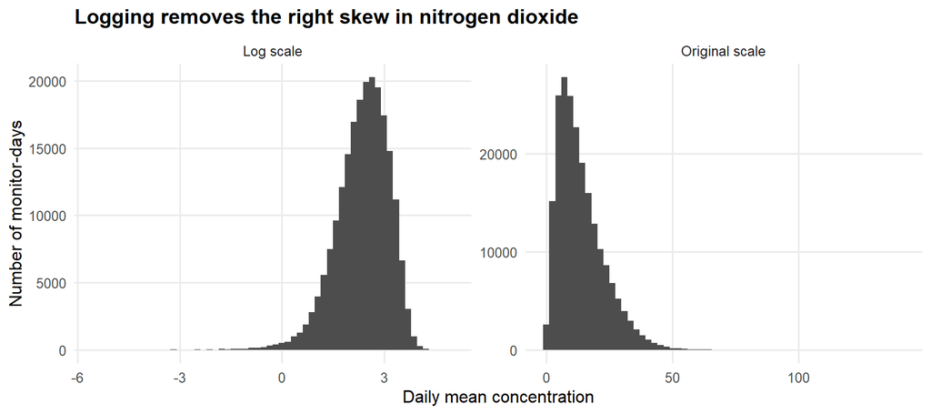

Figure 1: Daily mean nitrogen dioxide is strongly right-skewed on its original scale and approximately symmetric after a log transformation.

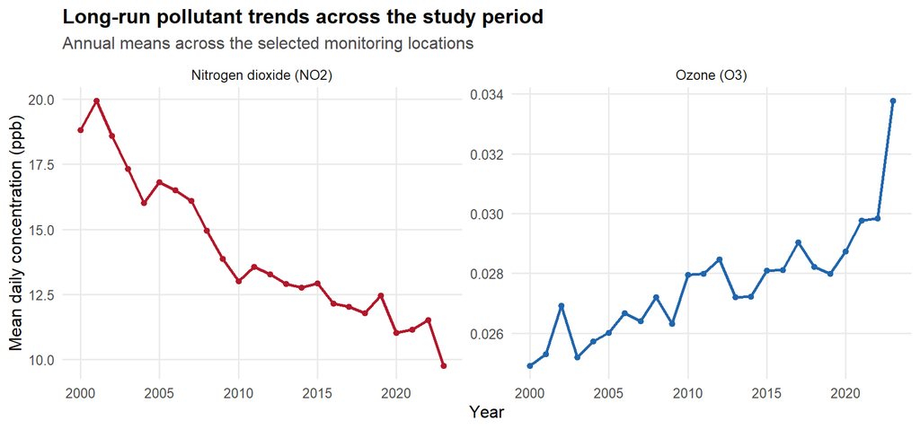

Figure 2: Annual mean concentrations across the selected monitoring locations. Nitrogen dioxide falls steeply over the study period while ozone drifts slightly upward, motivating year fixed effects.

# Results

## The weekly cycle

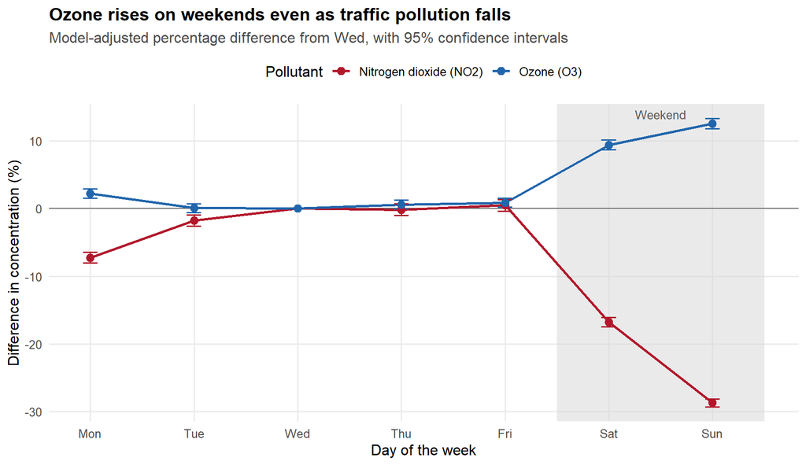

Figure 3: Model-adjusted percentage difference in concentration by day of the week, relative to Wednesday, with 95% confidence intervals. Estimates control for month, year, and monitoring location. Nitrogen dioxide falls sharply across the weekend while ozone rises.

Figure 3 is the central result. Nitrogen dioxide is flat from Tuesday through Friday, dips slightly on Monday, and then falls steeply: about 17% below Wednesday on Saturday and about 29% below on Sunday. Ozone traces the mirror image. It is flat midweek and then rises, reaching about 9% above Wednesday on Saturday and 13% above on Sunday. The confidence intervals are narrow enough that the weekday and weekend estimates do not overlap for either pollutant.

## Estimated weekend effect

Table 5: Estimated weekend effect from the binary specification. Coefficients are on the log scale; the final columns convert them to percentage differences.

| Pollutant | Coefficient (log scale) | Std. error | t statistic | p value | Change (%) | 95% CI (%) |
| --- | --- | --- | --- | --- | --- | --- |
| Nitrogen dioxide (NO2) | -0.2428 | 0.0026 | -93.7 | <1e-300 | -21.56 | [-21.95, -21.16] |
| Ozone (O3) | 0.0965 | 0.0020 | 47.6 | <1e-300 | 10.13 | [9.69, 10.57] |

Table 5 reports the binary specification. Weekend nitrogen dioxide is 21.6% lower than weekday nitrogen dioxide, with a 95% confidence interval running from 21.2% to 22% lower. Weekend ozone is 10.1% higher, with an interval running from 9.7% to 10.6% higher. Both p-values fall below any conventional threshold, so we reject both null hypotheses in favour of the directional alternatives stated in the introduction.

Table 6: Model fit statistics for the binary weekend specification.

| Pollutant | Observations | Parameters | Adjusted R-squared | Residual SE |
| --- | --- | --- | --- | --- |
| Nitrogen dioxide (NO2) | 212,807 | 55 | 0.527 | 0.539 |
| Ozone (O3) | 212,807 | 55 | 0.422 | 0.422 |

The models explain a little over half the variation in log NO<sub>2</sub> and about 42% of the variation in log O<sub>3</sub>. Most of that explanatory power comes from the location and month terms rather than the weekend indicator, which is expected: the weekly cycle is a real but modest component of day-to-day variation, most of which is driven by weather and geography.

## Validity checks

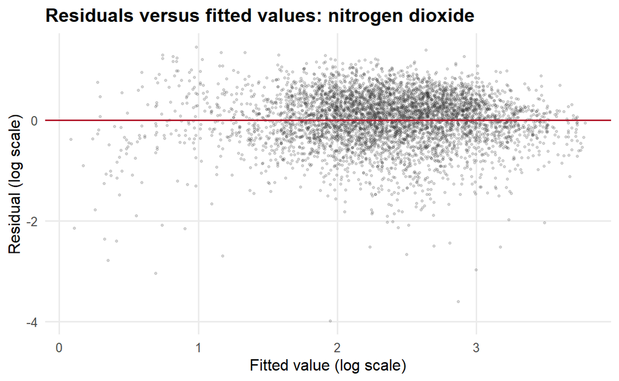

Figure 4: Residuals against fitted values for the nitrogen dioxide model, on a random sample of 5,000 monitor-days. The spread is broadly even across the fitted range, supporting the constant-variance assumption.

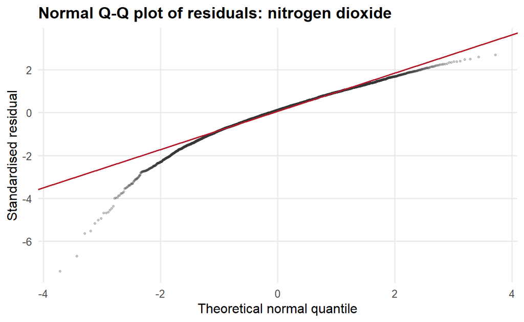

Figure 5: Normal quantile-quantile plot for the nitrogen dioxide model. The lower tail departs from the reference line, indicating residuals that are left- skewed and heavier-tailed than the normal distribution.

The residual plot in Figure 4 shows no funnel shape and no systematic curvature, so linearity on the log scale and constant variance are both reasonable. The quantile-quantile plot in Figure 5 is less flattering: the residuals are left-skewed and heavy-tailed, so the normality assumption fails. This matters less than it might appear. With more than 200,000 observations, the sampling distribution of the coefficients is governed by the central limit theorem rather than by the shape of individual residuals, so the standard errors and confidence intervals remain approximately valid. The p-values should nonetheless be read as approximate rather than exact.

A more serious issue is independence, which the design clearly violates: consecutive days at the same monitor are correlated, because weather persists. Positive serial correlation of this kind leaves the coefficients unbiased but makes the reported standard errors too small. The estimated effects are large enough that this is unlikely to overturn the conclusions, but the intervals in Table 5 should be treated as a lower bound on the true uncertainty.

# Discussion

## Main findings

Across 24 years and 20 urban monitoring locations, the weekly rhythm of human activity is clearly visible in the air. Nitrogen dioxide falls about 22% on weekends, and the day-by-day profile in Figure 3 shows that the decline tracks the working week almost exactly: flat from Tuesday to Friday, lower on Saturday, and lowest on Sunday. This is what a traffic-driven pollutant should look like, and it supports the traffic-marker hypothesis.

Ozone moves the other way, rising about 10% on weekends. The data therefore support the titration hypothesis as well. Both null hypotheses are rejected, and the opposite signs are the substantive finding: cutting emissions does not lower every pollutant, because the pollutant that harms people at ground level is partly destroyed by the very emissions that cause the rest of the problem.

## Why this may or may not be meaningful

The result is meaningful mainly because it is a caution against a natural intuition. If a city reduced weekday traffic to weekend levels, these estimates suggest it would enjoy substantially cleaner air in terms of nitrogen dioxide but might see ozone rise, at least in the urban core where NO<sub>x</sub> scavenging dominates. That trade-off is well established in atmospheric chemistry, and recovering it from a simple regression on public monitoring data is a reassuring sign that the estimates are picking up real chemistry rather than noise.

There are reasons for caution. The comparison is observational, not experimental. “Weekend” is a proxy for reduced commuting traffic, but weekends differ from weekdays in other ways too, including industrial activity, heavy goods traffic, and recreational travel, so the coefficient captures the whole bundle rather than traffic alone. The analysis also says nothing about *where* the ozone increase matters most; the titration effect is strongest in dense urban centres and can reverse downwind.

## Critique and possible extensions

Three limitations stand out. First, as noted in Section 3.3, the standard errors ignore serial correlation within monitoring sites and are therefore too small; clustering the standard errors by location, or aggregating to weekly averages, would give more honest intervals. Second, the analysis controls for season and year with fixed effects but includes no direct meteorological variables. Temperature, sunlight, and wind speed are the main drivers of ozone formation, and while there is no reason for weather to differ systematically between weekdays and weekends, adding weather data would tighten the model considerably. Third, restricting to the 20 best-covered locations buys a balanced panel at the cost of national representativeness; these are dense urban monitors, exactly the places where NO<sub>x</sub> titration is strongest, so the ozone result in particular should not be generalised to rural areas.

# Appendix

Table 7: Full day-of-week estimates for both pollutants, relative to Wednesday.

| Pollutant | Day | Change (%) | 95% CI (%) | p value |
| --- | --- | --- | --- | --- |
| Nitrogen dioxide (NO2) | Mon | -7.24 | [-8.02, -6.44] | 1.00e-66 |
| Nitrogen dioxide (NO2) | Tue | -1.75 | [-2.58, -0.91] | 4.83e-05 |
| Nitrogen dioxide (NO2) | Thu | -0.16 | [-1.01, 0.69] | 0.7092 |
| Nitrogen dioxide (NO2) | Fri | 0.48 | [-0.37, 1.34] | 0.2723 |
| Nitrogen dioxide (NO2) | Sat | -16.78 | [-17.48, -16.06] | < 1e-300 |
| Nitrogen dioxide (NO2) | Sun | -28.70 | [-29.31, -28.09] | < 1e-300 |
| Ozone (O3) | Mon | 2.23 | [1.55, 2.92] | 1.07e-10 |
| Ozone (O3) | Tue | 0.06 | [-0.6, 0.74] | 0.8526 |
| Ozone (O3) | Thu | 0.60 | [-0.07, 1.28] | 0.0788 |
| Ozone (O3) | Fri | 0.88 | [0.21, 1.56] | 0.0102 |
| Ozone (O3) | Sat | 9.41 | [8.68, 10.15] | 5.51e-152 |
| Ozone (O3) | Sun | 12.54 | [11.79, 13.3] | 1.38e-259 |

Table 8: Monitoring locations retained in the analysis sample.

| Location | Monitor-days |
| --- | --- |
| California - Los Angeles | 19,617 |
| New York - New York | 16,799 |
| California - Rubidoux | 15,668 |
| Arizona - Phoenix | 14,544 |
| Arkansas - North Little Rock | 11,271 |
| Texas - Houston | 11,104 |
| North Carolina - Charlotte | 10,536 |
| District Of Columbia - Washington | 10,515 |
| Texas - El Paso | 10,334 |
| Utah - Salt Lake City | 9,337 |
| Ohio - Cleveland | 8,747 |
| California - Concord | 8,539 |
| California - Vallejo | 8,450 |
| California - Bethel Island | 8,430 |
| Arizona - Tucson | 8,401 |
| Louisiana - Baton Rouge | 8,252 |
| California - Lompoc | 8,178 |
| California - San Pablo | 8,122 |
| California - Calexico | 8,003 |
| Colorado - Denver | 7,960 |